### MATH 420: Statistical Modeling

#### Fall 2021

### MLR: Randomization (Permutation) Tests (4.6)

```r
require(mosaic);require(car);require(leaps);require(MASS)
options(digits=3)
```

Inference for linear regression only holds if the appropriate conditions are met. What are those conditions?

We know how to assess whether these conditions are met, and we have learned a few techniques for correcting them when they are not (e.g. transformations). Today, we will learn a few techinques based on randomization for making *non-parametric* inferences. Such inferences do not rely on stringent assumptions about the distribution of the error terms.

In this example, suppose we are trying to explain a college student’s $GPA$ as a function of their score on the verbal section of the SAT (i.e. using an SLR).

```r
GPA = read.csv("http://personal.denison.edu/~whiteda/files/Teaching/FirstYearGPA.csv")
# Use only the non-null entries
GPA = subset(GPA, !is.na(GPA))
# How big is our sample?
nrow(GPA)
```

```
## [1] 219
```

First, let’s examine the relationship between these two variables graphically.

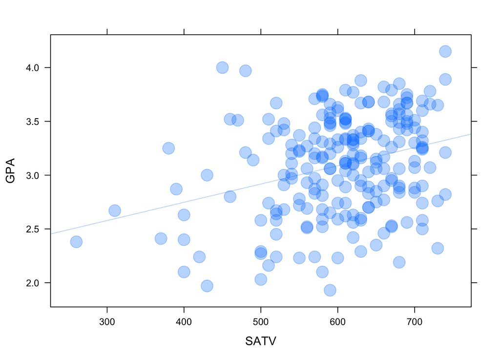

```r
xyplot(GPA ~ SATV, data=GPA, pch=19, cex=2, alpha=0.3, type=c("p","r"))
```

There appears to be some linear assocation between these variables, but it is not particularly strong. We can quantify this relationship using the correlation coefficient, which I am saving for reference later.

```r
cor.actual = with(GPA, cor(GPA, SATV))
cor.actual
```

```
## [1] 0.304
```

In this case the value of the correlation coefficient is about 0.3, which is not large, but does appear to be significantly different from 0. Recall we learned a test for correlation earlier.

```r
with(GPA, cor.test(GPA, SATV))#test to check for non-zero correlation; new command
```

```
##
##  Pearson's product-moment correlation
##
## data:  x and y
## t = 5, df = 217, p-value = 4e-06
## alternative hypothesis: true correlation is not equal to 0
## 95 percent confidence interval:
##  0.179 0.420
## sample estimates:
##   cor
## 0.304
```

This test confirms that the correlation between college GPA and SATV is most likely not zero, but the validity of this test requires the assumptions for simple linear regression to be met (in particular, the normality condition on the errors MUST hold). Let’s assume that in this case the assumptions are not met. Can we still feel confident that the correlation is non-zero?

If GPA and SATV were really correlated, then there is a real relationship binding the i-th value of GPA to the i-th value of SATV. In this case, it would not make sense to link the i-th value of GPA to the some other value of SATV. But if the correlation between these two variables was in fact zero, then it wouldn’t matter how we matched up the entries in the variables!

The basic idea of the randomization or permutation test is to shuffle the mapping between the two variables many times (i.e. sample *without replacement*), and examine the distribution of the resulting correlation coefficient. If the actual value of the correlation coefficient is a rare member of that distribution, then we have evidence that the true correlation is non-zero.

R can shuffle the data for us, and we can watch what happens to the regression lines in the shuffled data. We can also record summary statistics - like the correlation, to see how it behaves when we are “destroying” the relationships between the variables.

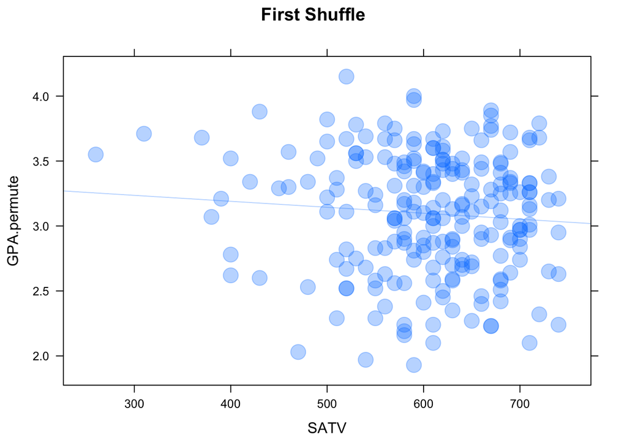

```r
GPA.permute = shuffle(GPA$GPA)
xyplot(GPA.permute ~ SATV, data=GPA, pch=19, cex=2, alpha=0.3, type=c("p","r"),main="First Shuffle")
```

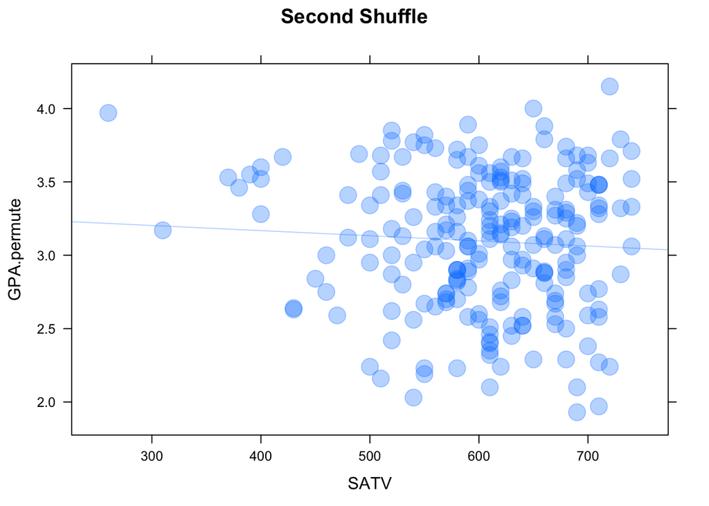

```r
GPA.permute = shuffle(GPA$GPA)
xyplot(GPA.permute ~ SATV, data=GPA, pch=19, cex=2, alpha=0.3, type=c("p","r"),main="Second Shuffle")
```

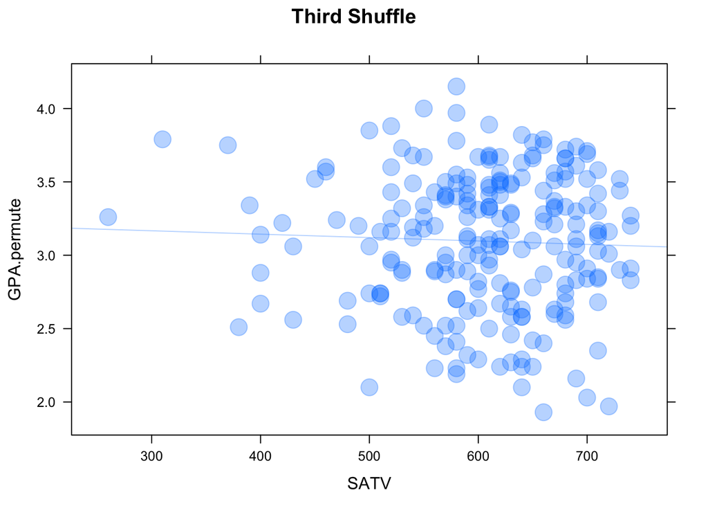

```r
GPA.permute = shuffle(GPA$GPA)
xyplot(GPA.permute ~ SATV, data=GPA, pch=19, cex=2, alpha=0.3, type=c("p","r"),main="Third Shuffle")
```

The procedure for the randomization test is simple. We simply shuffle the explanatory variable and compute the resulting correlation coefficient with the response variable (it remains this way for MLR too, you want each case to still have the same relationships between the response and OTHER predictors - you just shuffle the one predictor you want to learn about). But we do this many times, until we have a sense of the distribution of that correlation coefficient (or whatever statistic we are interested in). We then examine where the observed correlation (or other statistic) falls in that distribution.

```r
# Do this 1000 times
rtest = do(1000) * cor(shuffle(GPA$GPA), GPA$SATV)
head(rtest)
```

```
##        cor
## 1 -0.08764
## 2 -0.15470
## 3  0.00581
## 4 -0.11604
## 5  0.12339
## 6 -0.06301
```

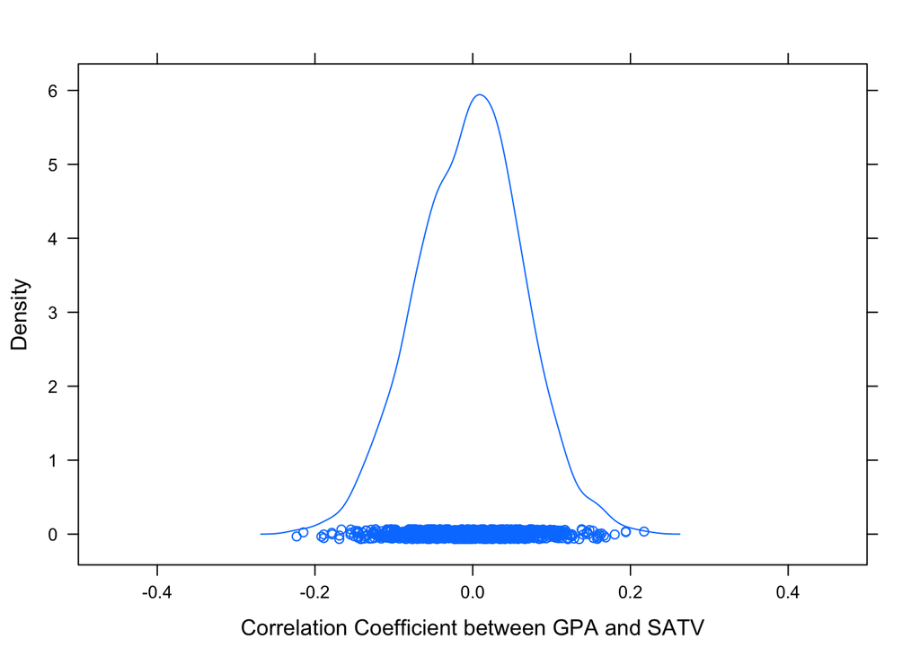

```r
densityplot(~cor, data=rtest, xlim=c(-0.5,0.5), xlab="Correlation Coefficient between GPA and SATV")
```

```r
cor.actual
```

```
## [1] 0.304
```

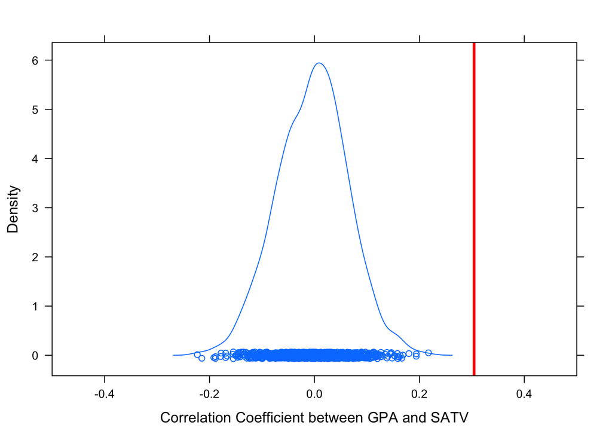

```r
ladd(panel.abline(v=cor.actual, col="red", lwd=3))
```

Of course, we can also explicitly find where in the distribution the observed correlation lies.

```r
bigger <- pdata(cor.actual, rtest$cor) # for each reshuffle, put a 1 into bigger if the correlation is bigger than cor.actual

# Count number of "successes" (i.e. bigger than cor.actual) over num trials:
length(subset(bigger,bigger == 1))/length(bigger) #provides area above cor.actual based on randomization distribution
```

```
## [1] 0
```

```r
# Just to show that pdata is not always all 0 or all 1...
#pdata(0, rtest$cor)
#pdata(0, rtest$cor, lower.tail=FALSE)
```

Finally, we can find a nonparametric 95% confidence interval for the correlation coefficient. The interpretation here is that actual correlation values in this interval would NOT be considered statistically significant.

```r
quantile(rtest$cor,c(0.025, 0.975)) # Note that .304 is way outside of this CI
```

```
##   2.5%  97.5%
## -0.137  0.126
```

Our actual correlation of 0.3 lies entirely above this interval, so we believe we have a statistically significant result.